# Clustering: Ejemplo básico

# K-Means Clustering

El método de K-Means basa su funcionamiento en agrupar los datos de entrada en un total de k conjuntos definidos por un centroide, cuya distancia con los puntos que pertenecen a cada uno de los datos es la menor posible. Los pasos del algoritmo son:

1. Definir un total de k centroides al azar.
2. Calcular las distancias de cada uno de los puntos de entrada a los k centroides, y asignar cada punto al centroide cuya distancia sea menor.
3. Actualizar la posición de los k centroides, calculando la posición promedio de todos los puntos que pertenecen a cada clase.
4. Repetir los pasos 2 y 3 hasta que los centroides no cambien de posición y, por lo tanto, las asignaciones de puntos entre clases no cambie.

Sin embargo, la cantidad óptima de centroides *k* a utilizar no se conoce necesariamente de antemano, por lo que es necesario aplicar una técnica conocida como el Elbow Method a fin de determinar dicho valor. Básicamente, este método busca seleccionar la cantidad ideal de grupos a partir de la optimización de la WCSS (Within Clusters Summed Squares).

Por otro lado, ya que los centroides iniciales se generan al azar, pueden obtenerse resultados distintos en cada ejecución del algoritmo, e incluso debido a las ubicaciones iniciales de los centroides, obtenerse al final soluciones que son mínimos locales en vez del global del conjunto de datos. Para solventar este problema, se propuso el algoritmo de k-means++ a fin de escoger los centroides iniciales que garantizaran la convergencia adecuada del modelo.

Entonces, para implementar el modelo de K-Means, comencemos por determinar la cantidad óptima de centroides a utilizar a partir del Elbow Method. Para ello, aplicaremos la función kmeans al conjunto de datos, variando en cada caso el valor de k, y acumulando los valores de WCSS obtenidos:

```r
set.seed(123)
wcss <- vector()
for(i in 1:20){
  wcss[i] <- sum(kmeans(dataClusters, i)$withinss)
}
```

Una vez calculados los valores de WCSS en función de la cantidad de centroides k, vamos a graficar los resultados:

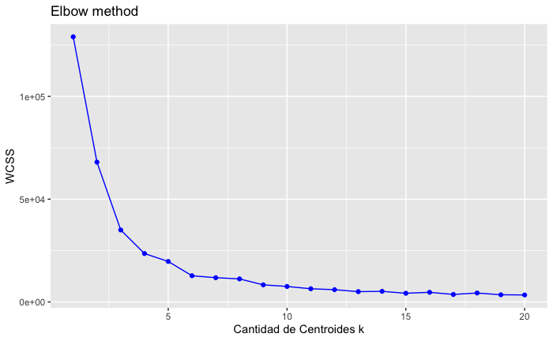

```r
ggplot() + geom_point(aes(x = 1:20, y = wcss), color = 'blue') +
  geom_line(aes(x = 1:20, y = wcss), color = 'blue') +
  ggtitle("Elbow method") +
  xlab('Cantidad de Centroides k') +
  ylab('WCSS')
```

A partir de la curva obtenida podemos ver cómo a medida que se aumenta la cantidad de clusters, el valor de WCSS disminuye de tal forma que la gráfica adopta una forma de codo.

Para seleccionar el valor óptimo de k, se escoje entonces ese punto en donde ya no se dejan de producir variaciones importantes del valor de WCSS al aumentar k. En este caso, vemos que esto se produce a partir de k >= 7, por lo que evaluaremos los resultados del agrupamiento, por ejemplo, con los valores de 7, 8 y 9 a fin de observar el comportamiento del modelo.

Finalmente, podemos aplicar el algoritmo con la cantidad de k seleccionada:

```r
set.seed(1234)
modeloKMeans <- kmeans(dataClusters, 7, iter.max = 1000)
```

Veamos el resultado del agrupamiento

Primero, vemos el resultado de los clusters. ¿Sabes interpretar los valores que se muestran?

```r
modeloKMeans
```

```
K-means clustering with 7 clusters of sizes 84, 89, 128, 104, 181, 46, 156

Cluster means:
          X         Y
1 10.404762  4.594048
2 11.000562 11.879775
3 32.694531 22.137891
4 33.142788  8.793750
5 19.520994  6.979834
6 21.413043 23.126087
7  9.074038 23.389744

Clustering vector:
  [1] 6 7 7 7 7 7 7 7 7 7 7 7 7 7 7 7 7 7 7 7 7 7 7 7 7 7 7 7 7 7 7 7 7 7 7 7 7 7 7 7 7 7 7 7 7 7 7 7 7
 [50] 7 7 7 7 7 7 7 7 7 7 7 7 7 7 7 7 7 7 7 7 7 7 7 7 7 7 7 7 7 7 7 7 7 7 7 7 7 7 7 7 7 7 7 7 7 7 7 7 7
 [99] 7 7 7 7 7 7 7 7 7 7 7 7 7 7 7 7 7 7 7 2 2 2 7 7 7 7 7 7 7 7 7 7 7 7 7 7 7 7 7 7 7 7 7 7 7 7 7 7 7
[148] 7 7 7 7 7 7 7 7 7 7 2 2 2 2 2 7 7 7 2 2 2 2 2 2 2 2 2 2 2 2 2 2 2 2 2 2 2 2 2 2 2 2 2 2 2 2 2 2 2
[197] 2 2 2 2 2 2 2 2 2 2 2 2 2 2 2 2 2 2 2 2 2 2 2 2 2 2 2 2 2 2 2 2 2 2 2 2 1 1 1 2 2 2 2 1 1 1 1 1 1
[246] 1 2 2 2 2 2 2 5 5 5 2 5 2 5 5 2 2 5 1 1 1 1 1 1 1 1 1 1 1 1 1 1 1 1 1 1 1 1 1 1 1 1 1 1 1 1 1 1 1
[295] 5 1 1 1 1 1 1 1 1 1 5 5 5 5 5 5 5 5 5 5 5 5 5 5 5 5 5 5 5 5 5 5 5 5 5 5 5 5 5 5 5 5 5 5 5 5 5 5 5
[344] 5 5 5 5 5 5 5 5 5 5 5 5 5 5 5 5 5 5 5 5 5 5 5 5 5 5 5 5 5 5 5 5 5 5 5 5 5 5 5 5 5 5 5 5 5 5 5 5 5
[393] 5 5 5 5 5 5 5 5 5 5 5 5 5 5 5 5 5 5 5 5 5 5 5 5 5 5 5 5 5 5 5 5 5 5 5 5 5 5 5 5 5 5 5 5 5 5 5 5 5
[442] 5 5 5 5 5 5 5 5 5 5 5 5 5 5 5 5 5 5 5 5 5 5 5 5 5 5 5 5 5 5 5 5 5 5 5 5 4 4 4 4 4 4 4 4 4 4 4 4 4
[491] 4 4 4 4 4 4 4 4 4 4 4 4 4 4 4 4 4 4 4 4 4 4 4 4 4 4 4 4 4 4 4 4 4 4 4 4 4 4 4 4 4 4 4 4 4 4 4 4 4
[540] 4 4 4 4 4 4 4 4 4 4 4 4 4 4 4 4 4 4 4 4 4 4 4 4 4 4 4 4 4 4 4 4 4 4 4 4 4 4 4 4 4 4 3 3 3 3 3 3 3
[589] 3 3 3 3 3 3 3 3 3 3 3 3 3 3 3 3 3 3 3 3 3 3 3 3 3 3 3 3 3 3 3 3 3 3 3 3 3 3 3 3 3 3 3 3 3 3 3 3 3
[638] 3 3 3 3 3 3 3 3 3 3 3 3 3 3 3 3 3 3 3 3 3 3 3 3 3 3 3 3 3 3 3 3 3 3 3 3 3 3 3 3 3 3 3 3 3 3 3 3 3
[687] 3 3 3 3 3 3 3 3 3 3 3 3 3 3 3 3 3 3 3 3 3 3 3 6 6 6 6 6 6 6 6 6 6 6 6 6 6 6 6 6 6 6 6 6 6 6 6 6 6
[736] 6 6 6 6 6 6 6 6 6 6 6 6 6 6 6 6 6 6 6 1 1 1 1 1 1 1 1 1 1 1 1 1 1 1 1 1 1 1 1 1 1 1 1 1 1 1 1 1 1
[785] 1 1 1 1

Within cluster sum of squares by cluster:
[1] 1223.7101 1600.4011 1707.7149 1216.9905 2492.9091  267.3109 2720.9859
 (between_SS / total_SS =  91.3 %)

Available components:

[1] "cluster"      "centers"      "totss"        "withinss"     "tot.withinss" "betweenss"
[7] "size"         "iter"         "ifault"
```

Segundo, su representación grafica.

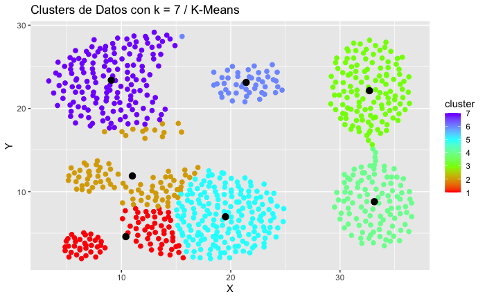

```r
dataClusters$cluster <- modeloKMeans$cluster
ggplot() + geom_point(aes(x = X, y = Y, color = cluster), data = dataClusters, size = 2) +
  scale_colour_gradientn(colours=rainbow(4)) +
  geom_point(aes(x = modeloKMeans$centers[, 1], y = modeloKMeans$centers[, 2]), color = 'black', size = 3) +
  ggtitle('Clusters de Datos con k = 7 / K-Means') +
  xlab('X') + ylab('Y')
```

En la gráfica se representa cada cluster con un color diferente, y además se muestra la posición de cada centroide en negro.

Al validar con k = 8 y 9 tenemos:

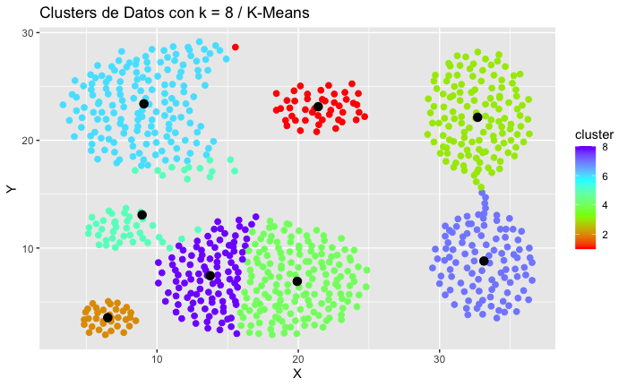

```r
set.seed(123)
modeloKMeans2 <- kmeans(dataClusters, 8, iter.max = 1000, nstart = 10)
dataClusters$cluster <- modeloKMeans2$cluster
ggplot() + geom_point(aes(x = X, y = Y, color = cluster), data = dataClusters, size = 2) +
  scale_colour_gradientn(colours=rainbow(4)) +
  geom_point(aes(x = modeloKMeans2$centers[, 1], y = modeloKMeans2$centers[, 2]), color = 'black', size = 3) +
  ggtitle('Clusters de Datos con k = 8 / K-Means') +
  xlab('X') + ylab('Y')
```

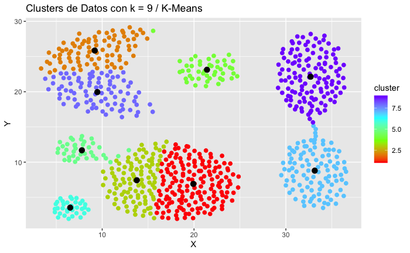

```r
set.seed(123)
modeloKMeans3 <- kmeans(dataClusters, 9, iter.max = 1000, nstart = 10)
dataClusters$cluster <- modeloKMeans3$cluster
ggplot() + geom_point(aes(x = X, y = Y, color = cluster), data = dataClusters, size = 2) +
  scale_colour_gradientn(colours=rainbow(4)) +
  geom_point(aes(x = modeloKMeans3$centers[, 1], y = modeloKMeans3$centers[, 2]), color = 'black', size = 3) +
  ggtitle('Clusters de Datos con k = 9 / K-Means') +
  xlab('X') + ylab('Y')
```

Al incrementar el valor de k tendremos entonces agrupamientos que recogen partes específicas de los datos de entrada, incluso llegando a dividir en dos grupos distintos a lo que inicialmente parece ser un solo grupo, como es el caso de los datos presentes en la parte superior izquierda de la gráfica cuando k = 9. Así, vemos cómo el algoritmo de K-Means es capaz de producir de manera natural estos agrupamientos a partir de las semejanzas de los datos, y dichas clases generadas de hecho concuerdan con la intuición propia al observar los datos de entrada.

# Hierarchical Clustering

El Agrupamiento Jerárquico es un método de agrupamiento que basa su funcionamiento en encontrar jerarquías en los datos de entrada a partir de generar grupos basados en la cercanía o semejanza de los datos. Se empieza calculando los puntos de los datos de entrada que estén más cercanos y se crea un grupo entre ellos. Luego se calculan los siguientes pares más cercanos y de manera ascendente se van generando grupos de clases que, de manera visual podrán observarse a partir de la construcción de un Dendrograma. Las clases, entonces, estarán definidas por la cantidad de líneas verticales del dendrograma (como veremos más adelante), y la selección del número de clases óptima para el conjunto de datos se podrá estimar de este mismo diagrama.

Así, para implementar el agrupamiento jerárquico en R y construir el dendrograma, se hace uso de la función *hclust*. Además, usaremos la función *ggdendrogram* del paquete *ggdendro* para visualizar el dendrograma:

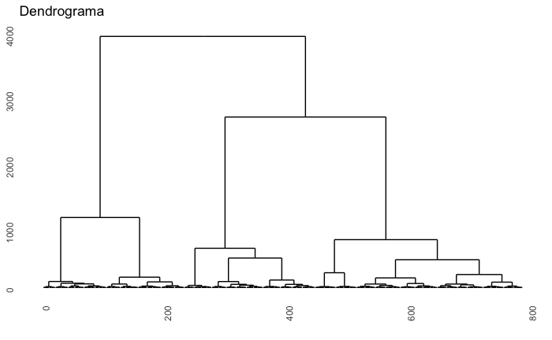

```r
dendrograma <- hclust(dist(dataClusters, method = 'euclidean'), method = 'ward.D')
ggdendrogram(dendrograma, rotate = FALSE, labels = FALSE, theme_dendro = TRUE) +
  labs(title = "Dendrograma")
```

```r
modeloJerarquico <- hclust(dist(dataClusters, method = 'euclidean'), method = 'ward.D')
gruposModelo1 <- cutree(modeloJerarquico, k = 3)
dataClusters$cluster <- gruposModelo1
```

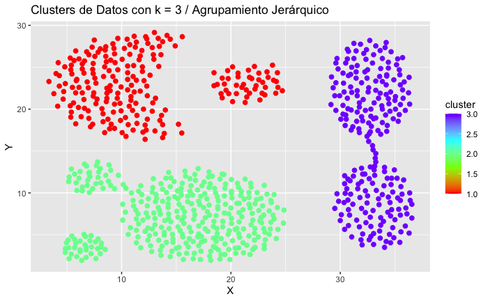

```r
ggplot() + geom_point(aes(x = X, y = Y, color = cluster), data = dataClusters, size = 2) +
  scale_colour_gradientn(colours=rainbow(4)) +
  ggtitle('Clusters de Datos con k = 3 / Agrupamiento Jerárquico') +
  xlab('X') + ylab('Y')
```

En el caso de k = 3, se observa que el algoritmo selecciona de manera adecuada los 3 grandes grupos generales que presenta el conjunto de datos.

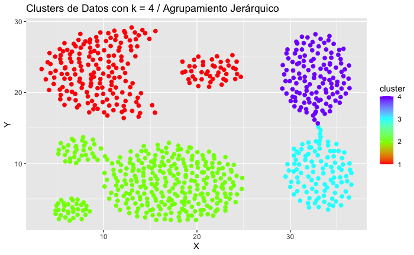

```r
modelo2 <- cutree(modeloJerarquico, k = 4)
dataClusters$cluster <- modelo2
ggplot() + geom_point(aes(x = X, y = Y, color = cluster), data = dataClusters, size = 2) +
  scale_colour_gradientn(colours=rainbow(4)) +
  ggtitle('Clusters de Datos con k = 4 / Agrupamiento Jerárquico') +
  xlab('X') + ylab('Y')
```

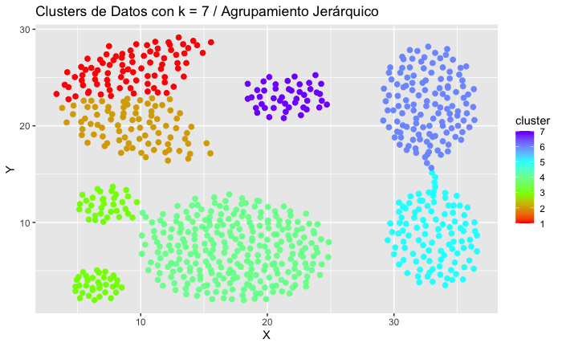

```r
modelo3 <- cutree(modeloJerarquico, k = 7)
dataClusters$cluster <- modelo3
ggplot() + geom_point(aes(x = X, y = Y, color = cluster), data = dataClusters, size = 2) +
  scale_colour_gradientn(colours=rainbow(4)) +
  ggtitle('Clusters de Datos con k = 7 / Agrupamiento Jerárquico') +
  xlab('X') + ylab('Y')
```

Se observa que al igual que el caso de K-Means, progresivamente se van obteniendo agrupamientos que separan las clases visibles en el conjunto de datos de una manera adecuada. Aunque no tienen información previa de etiquetas o clases predefinidas de los datos, los algoritmos de clustering pueden encontrar las clases naturales que existen en los datos a partir de las simulitudes entre ellos.